# FRAPPE-AOA

William Cooper

12/18/2014

The speed run from 15:50:00 to 15:55:00 on FRAPPE flight 4 provides good data for determining the angle-of-attack sensitivity coefficients. The basic equation that provides a reference for calibration is:

$\alpha_{\mathrm{ref}}=\theta-\frac{W_p}{V}=b_0+b_1\frac{\Delta p}{q}$

where $\theta$=PITCH, $W_p$=GGVSPD, $V$=TASX, $\Delta p$=ADIFR, and $q$=QCF. The choice for representing q is based on QCF being more reliable than QCR and not requiring prior pressure-defect correction as does PSXC (the use of which introduces circularity in the calculation because the pressure correction itself depends on angle of attack). The left equality of (1) relies on the vertical wind being zero, so the use of this result depends on the calibration maneuver being flown in air without vertical motion.

```r
Flight <- "rf04"
Project = "FRAPPE"
fname = sprintf("%s%s/%s%s.nc", DataDirectory (), Project, Project, Flight)
VarNames <- c("TASX", "ADIFR", "PITCH", "QCF", "GGVSPDB")
Data <- getNetCDF (fname, VarNames, Start=155000, End=155500)
if (!"GGVSPD" %in% names(Data)) {
  Data$GGVSPD <- Data$GGVSPDB
}
attach(Data)

Data$AOAREF <- PITCH - asin(GGVSPD/TASX) *180 / pi
Data$AQR <- ADIFR / QCF # basic pressure ratio for AOA
```

```r
fmy <- lm (AOAREF ~ AQR, data=Data)
print (summary (fmy))
```

```
##
## Call:
## lm(formula = AOAREF ~ AQR, data = Data)
##
## Residuals:
##       Min        1Q    Median        3Q       Max
## -0.262232 -0.069183 -0.009044  0.044996  0.299219
##
## Coefficients:
##             Estimate Std. Error t value Pr(>|t|)
## (Intercept)  4.85197    0.01397   347.3   <2e-16 ***
## AQR         13.22995    0.05312   249.1   <2e-16 ***
## ---
## Signif. codes:  0 '***' 0.001 '**' 0.01 '*' 0.05 '.' 0.1 ' ' 1
##
## Residual standard error: 0.1085 on 299 degrees of freedom
## Multiple R-squared:  0.9952, Adjusted R-squared:  0.9952
## F-statistic: 6.204e+04 on 1 and 299 DF,  p-value: < 2.2e-16
```

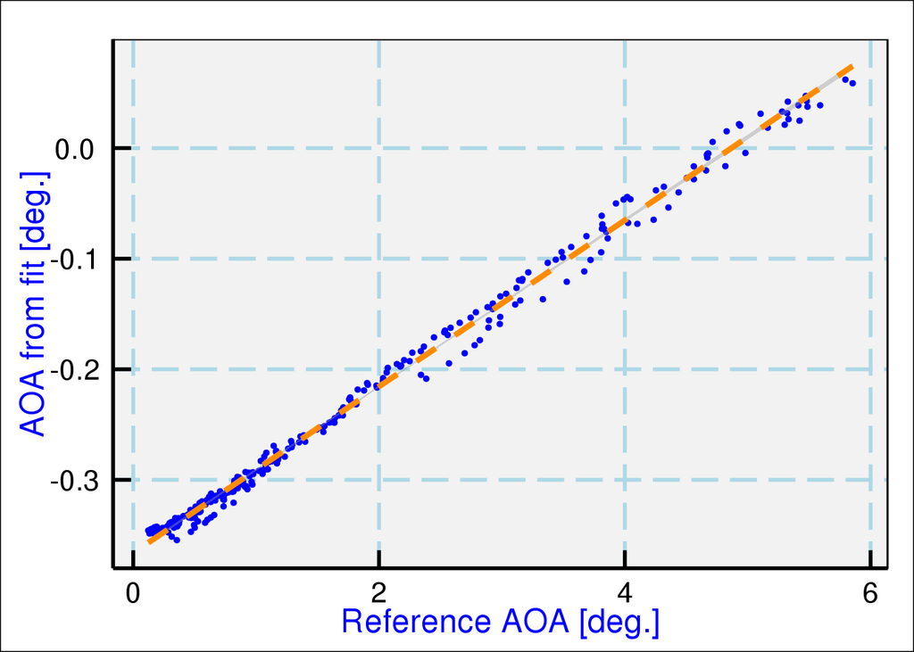

```r
cfr <- coefficients (fmy)
A1 <- cfr[1] + cfr[2] * Data$AQR
#plot (AOAREF, A1, pch=16, cex=0.8, col='blue', xlab="Ref. AOA", ylab="fit AOA")
#lines (c(-3.,6.), c(-3.,6.), lty=2, lwd=3, col='darkorange')
detach (Data)
g <- ggplot (data=Data, aes (x=AOAREF, y=AQR))
g <- g + geom_point (pch=20, col='blue')
g <- g + geom_smooth (method='lm', col='darkorange', lty=2, lwd=1.5)
g <- g + xlab ("Reference AOA [deg.]") + ylab ("AOA from fit [deg.]") + theme_WAC()
print (g)
```

The best-fit coefficients obtained by fitting (1) to the speed-run data are $b_0$ = 4.8519718 and $b_1$ = 13.2299466. The residual standard error is 0.11 and the square of the correlation coefficient is 0.995, so the fit is very good.

**Reproducibility:**

**Attachments:**  
FRAPPE-AOA.Rmd  
FRAPPE-AOA.pdf  
FRAPPE-AOA.Rdata  
SessionInfo

**Some relevant cal coefficients:**  
QCF:CalibrationCoefficients = 0.264f, 17.277f, 0.001f ;  
ADIFR:CalibrationCoefficients = -0.00765103f, 7.01173f, 0.00217793f ;